# Analysis of longitudinal data

## Loading and inspecting the RATS data

I downloaded this data set from https://raw.githubusercontent.com/KimmoVehkalahti/MABS/master/Examples/data/rats.txt, and then wrangled it for longitudinal analysis purposes. The data is originally from a nutrition study comparing three groups of rats (Crowder and Hand, 1990).

```r
# Load the wrangled RATSL data
ratsl <- read.csv("data/RATSL.csv")

# Convert categorical variables to factors
ratsl$ID <- factor(ratsl$ID)
ratsl$Group <- factor(ratsl$Group)
```

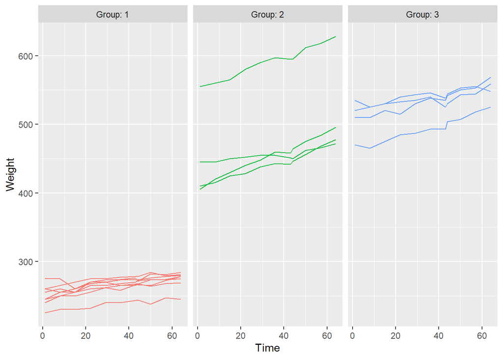

```r
ggplot(ratsl, aes(x = Time, y = Weight, Group = ID, col = Group)) +
  geom_line() +
  scale_linetype_manual(values = rep(1:10, times=4)) +
  facet_grid(. ~ Group, labeller = label_both) +
  theme(legend.position = "none") +
  scale_y_continuous(limits = c(min(ratsl$Weight), max(ratsl$Weight)))
```

The three groups of rats were on different diets. The rats were weighed approximately weekly. Their weights are depicted in the plot above. You can see that there were differences in their weights in the beginning of diets. Most notably the weight of all rats in group 1 was lower than in the two other groups. Also, it seems that in each group there is one rat whose weight differs from other rats in the same group. Also, you can see here that there were very few rats in each group. The rats who were heaviest in the beginning tend to have heavier weight through the diet, a phenomenon which is called tracking.

Next, I’ll standardise the data (subtract the measurement point mean from the observed values and divide by that measurement point’s standard deviation).

```r
ratsl <- ratsl %>%
  group_by(Time) %>%
  mutate(stdWeight = ((Weight-mean(Weight))/sd(Weight))) %>%
  ungroup()
```

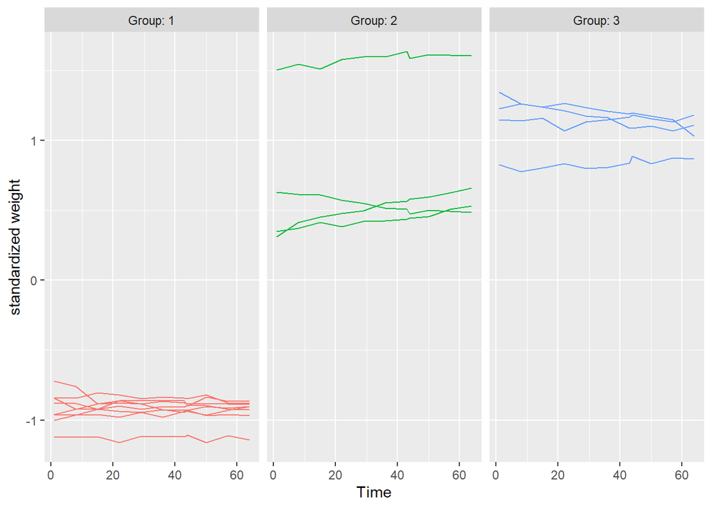

```r
ggplot(ratsl, aes(x = Time, y = stdWeight, Group = ID, col = Group)) +
  geom_line() +
  scale_linetype_manual(values = rep(1:10, times=4)) +
  facet_grid(. ~ Group, labeller = label_both) +
  theme(legend.position = "none") +
  scale_y_continuous(name = "standardized weight")
```

Above is the same kind of graph as before but this time with standardised values.

Next, I’ll create summary data and plot the means of each group at each measurement point with standard errors.

```r
# Number of days, baseline (day 1) included
n <- ratsl$Time %>% unique() %>% length()

# Summary data with mean and standard error of Weight by Group and Time
ratss <- ratsl %>%
  group_by(Group, Time) %>%
  summarise( mean = mean(Weight), se = sd(Weight)/sqrt(n) ) %>%
  ungroup()
glimpse(ratss)
```

```
## Rows: 33
## Columns: 4
## $ Group <fct> 1, 1, 1, 1, 1, 1, 1, 1, 1, 1, 1, 2, 2, 2, 2, 2, 2, 2, 2, 2, 2...
## $ Time  <int> 1, 8, 15, 22, 29, 36, 43, 44, 50, 57, 64, 1, 8, 15, 22, 29, 3...
## $ mean  <dbl> 250.625, 255.000, 254.375, 261.875, 264.625, 265.000, 267.375...
## $ se    <dbl> 4.589478, 3.947710, 3.460116, 4.100800, 3.333956, 3.552939, 3...
```

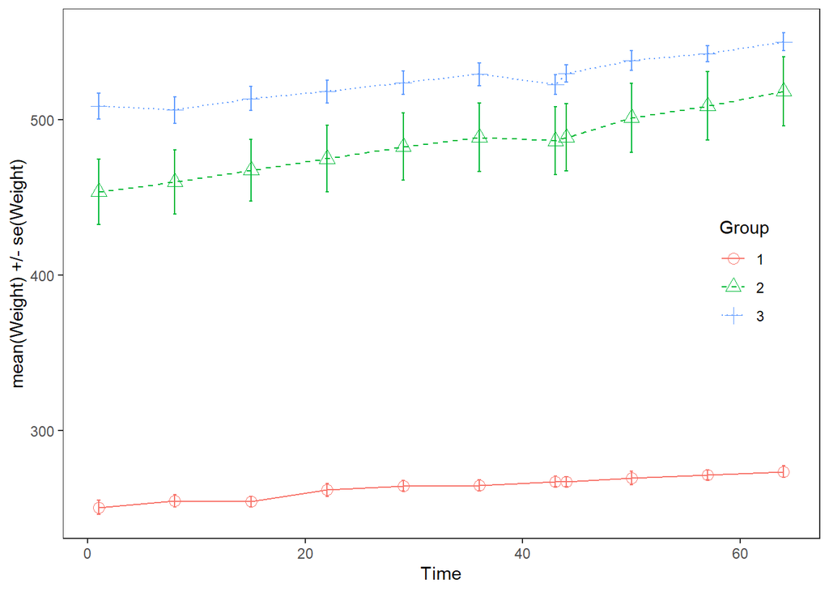

```r
# Plot the mean profiles
ggplot(ratss, aes(x = Time, y = mean, linetype = Group, shape = Group, col = Group)) +
  geom_line() +
  scale_linetype_manual(values = c(1,2,3)) +
  geom_point(size=3) +
  scale_shape_manual(values = c(1,2,3)) +
  geom_errorbar(aes(ymin=mean-se, ymax=mean+se, linetype="1"), width=0.3) +
  theme_bw() +
  theme(panel.grid.major = element_blank(), panel.grid.minor = element_blank()) +
  theme(legend.position = c(0.9,0.5)) +
  scale_y_continuous(name = "mean(Weight) +/- se(Weight)")
```

The mean weights seem to be increasing over time in all groups. The variability within group 1 is smaller than in the other groups. Group 2 has the largest variability.

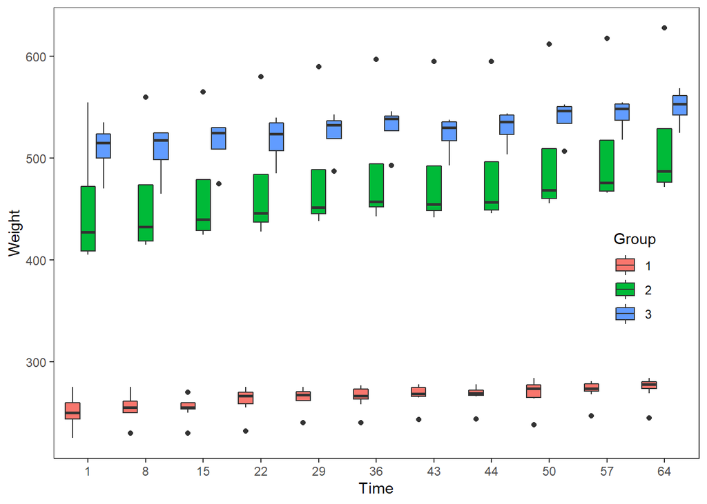

```r
ggplot(ratsl, aes(x = factor(Time), y = Weight, fill = Group)) +
  geom_boxplot(position = position_dodge(width = 0.8)) +
  theme_bw() +
  theme(panel.grid.major = element_blank(), panel.grid.minor = element_blank()) +
  theme(legend.position = c(0.9,0.4)) +
  scale_x_discrete(name = "Time")
```

Above is another way to plot the same data. This plot has side-by-side box plots of the group weights in each measurement point. In this plot the outliers can again be observed.

## Summary measure analysis

Summary measure method is simple, but it may be helpful in initial assessment on longitudinal data. I’ll create summary data of weights during the diet and excluding the starting weight.

```r
# Create summary data
rats_sum <- ratsl %>%
  filter(Time > 1) %>%
  group_by(Group, ID) %>%
  summarise( mean=mean(Weight) ) %>%
  ungroup()
```

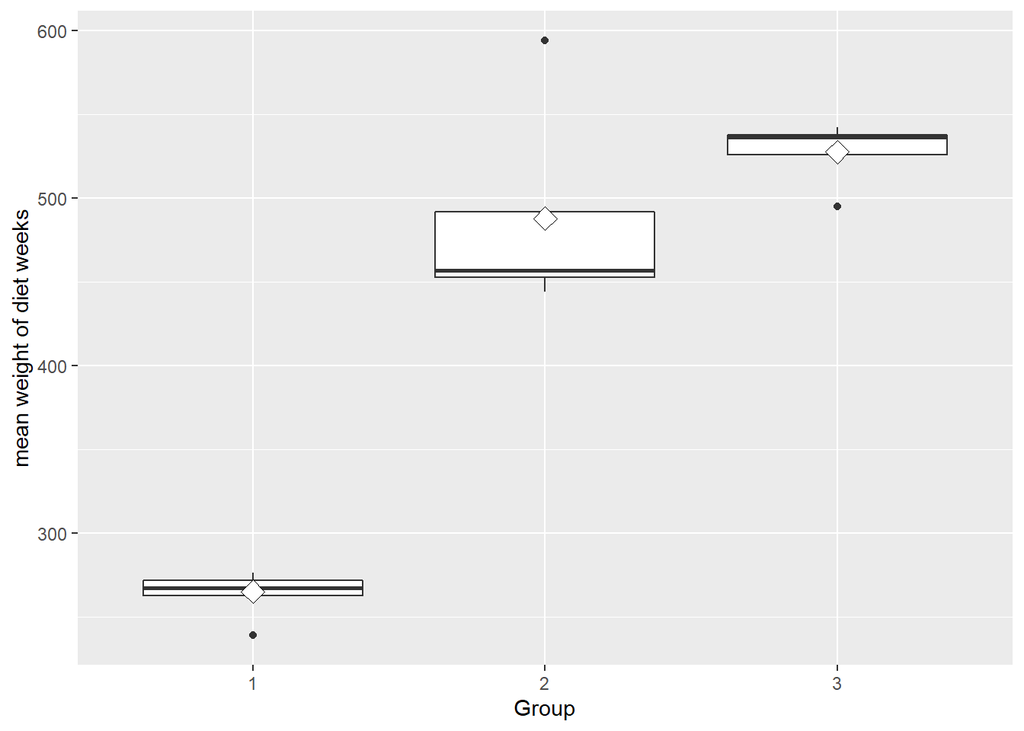

```r
ggplot(rats_sum, aes(x = Group, y = mean)) +
  geom_boxplot() +
  stat_summary(fun.y = "mean", geom = "point", shape=23, size=4, fill = "white") +
  scale_y_continuous(name = "mean weight of diet weeks")
```

Here are boxplots of mean weights of each group. There is one outlier in each group. I’ll remove the outliers from the data.

```r
# Remove the outliers
rats_no_out <- rats_sum %>%
  filter(ID != 2 & ID != 12 & ID != 13)
```

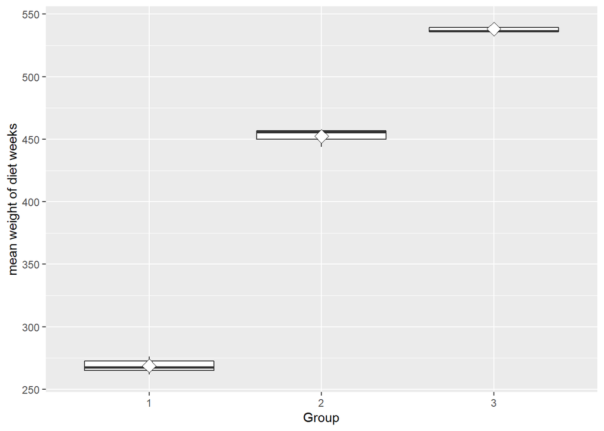

```r
ggplot(rats_no_out, aes(x = Group, y = mean)) +
  geom_boxplot() +
  stat_summary(fun.y = "mean", geom = "point", shape=23, size=4, fill = "white") +
  scale_y_continuous(name = "mean weight of diet weeks")
```

This is how the boxplots look without the outliers. Let’s compare the groups using ANOVA:

```r
# ANOVA of the data without outliers
summary(aov(mean ~ Group, data = rats_no_out))
```

```
##             Df Sum Sq Mean Sq F value             Pr(>F)
## Group        2 176917   88458    2836 0.0000000000000169 ***
## Residuals   10    312      31
## ---
## Signif. codes:  0 '***' 0.001 '**' 0.01 '*' 0.05 '.' 0.1 ' ' 1
```

The summary of ANOVA shows that the group weights differ significantly. However, the summary does not tell which groups differ from each other. I’ll perform Tukey test to find out:

```r
TukeyHSD(aov(mean ~ Group, data = rats_no_out))
```

```
##   Tukey multiple comparisons of means
##     95% family-wise confidence level
##
## Fit: aov(formula = mean ~ Group, data = rats_no_out)
##
## $Group
##          diff       lwr       upr p adj
## 2-1 183.64286 173.07885 194.20686     0
## 3-1 269.50952 258.94552 280.07353     0
## 3-2  85.86667  73.36717  98.36617     0
```

The Tukey test reveals that all groups differ from one another. None of the 95% confidence intervals includes zero. The biggest difference in weight is between groups 1 and 3.

The weight at the beginning of the diet is most likely correlated with the outcome measure of weight. Therefore, I’ll use the starting weight as the baseline covariate in the analysis:

```r
# Add the baseline from the original data
baseline <- ratsl %>% filter(Time==1) %>% rename(baseline = Weight) %>% filter(ID != 2 & ID != 12 & ID != 13)
rats_no_out2 <-rats_no_out %>% mutate(baseline)
```

```r
# ANCOVA of the data without outliers
summary(aov(mean ~ baseline + Group, data = rats_no_out2))
```

```
##             Df Sum Sq Mean Sq F value             Pr(>F)
## baseline     1 174926  174926 6630.94 0.0000000000000322 ***
## Group        2   2065    1033   39.15 0.0000362803291508 ***
## Residuals    9    237      26
## ---
## Signif. codes:  0 '***' 0.001 '**' 0.01 '*' 0.05 '.' 0.1 ' ' 1
```

Here we see that the baseline weight is strongly related to weight after diets have begun. Also, there are still differences between the groups after conditioning on the baseline weight.

# Loading and inspecting BPRS data

I downloaded this data set from https://raw.githubusercontent.com/KimmoVehkalahti/MABS/master/Examples/data/BPRS.txt, and then wrangled it for longitudinal analysis purposes. This data have psychiatric rating scale (BPRS) measurements from 40 male subjects in two treatment groups. I have converted the data to long format. Let’s glimpse the data and check how the 40 first rows look like:

```r
# Load the wrangled BPRSL data
bprsl <- read.csv("data/BPRSL.csv")

# Convert categorical variables to factors
bprsl$treatment <- factor(bprsl$treatment)
bprsl$subject <- factor(bprsl$subject)
bprsl$ID <- factor(bprsl$ID)
```

```r
glimpse(bprsl)
```

```
## Rows: 360
## Columns: 6
## $ treatment <fct> 1, 1, 1, 1, 1, 1, 1, 1, 1, 1, 1, 1, 1, 1, 1, 1, 1, 1, 1, ...
## $ subject   <fct> 1, 2, 3, 4, 5, 6, 7, 8, 9, 10, 11, 12, 13, 14, 15, 16, 17...
## $ ID        <fct> 1, 2, 3, 4, 5, 6, 7, 8, 9, 10, 11, 12, 13, 14, 15, 16, 17...
## $ weeks     <chr> "week0", "week0", "week0", "week0", "week0", "week0", "we...
## $ bprs      <int> 42, 58, 54, 55, 72, 48, 71, 30, 41, 57, 30, 55, 36, 38, 6...
## $ week      <int> 0, 0, 0, 0, 0, 0, 0, 0, 0, 0, 0, 0, 0, 0, 0, 0, 0, 0, 0, ...
```

```r
head(bprsl, n = 40)
```

```
##    treatment subject ID weeks bprs week
## 1          1       1  1 week0   42    0
## 2          1       2  2 week0   58    0
## 3          1       3  3 week0   54    0
## 4          1       4  4 week0   55    0
## 5          1       5  5 week0   72    0
## 6          1       6  6 week0   48    0
## 7          1       7  7 week0   71    0
## 8          1       8  8 week0   30    0
## 9          1       9  9 week0   41    0
## 10         1      10 10 week0   57    0
## 11         1      11 11 week0   30    0
## 12         1      12 12 week0   55    0
## 13         1      13 13 week0   36    0
## 14         1      14 14 week0   38    0
```

[output cut: 26 more lines]

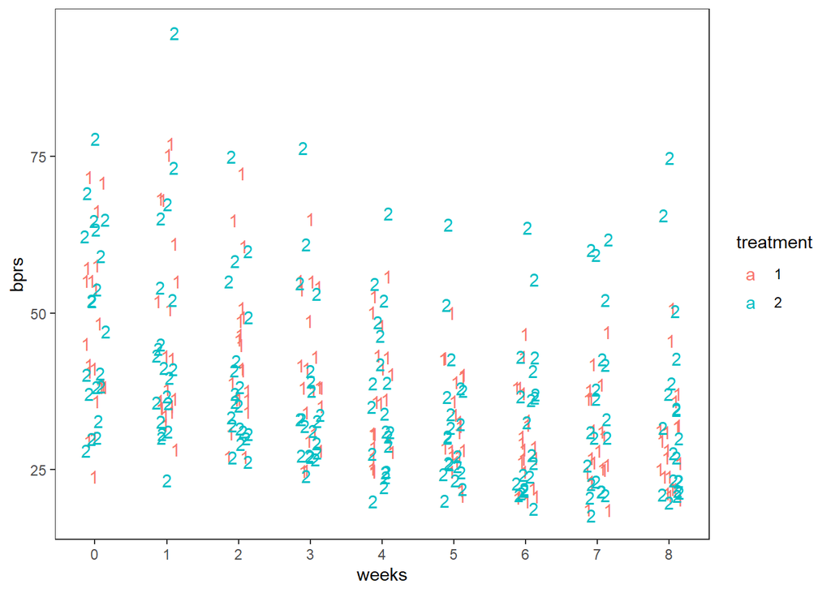

```r
ggplot(bprsl, aes(x = week, y = bprs, group = ID, col = treatment)) +
  geom_text(position = position_jitter(width = 0.15), aes(label = treatment)) +
  scale_x_continuous(name = "weeks", breaks = seq(0, 8, 1)) +
  scale_y_continuous(name = "bprs") +
  theme_bw() +
  theme(panel.grid.major = element_blank(), panel.grid.minor = element_blank())
```

The plot above shows the bprs scores of subjects belonging to the two groups each measurement week. The two groups do not seem to differ from each other very clearly.

## Fitting linear mixed model to the data

I’ll fit a multiple linear regression model with bprs as response and week and treatment as explanatory variables.

```r
bprs_reg <- lm(bprs ~ week + treatment, data = bprsl)
summary(bprs_reg)
```

```
##
## Call:
## lm(formula = bprs ~ week + treatment, data = bprsl)
##
## Residuals:
##     Min      1Q  Median      3Q     Max
## -22.454  -8.965  -3.196   7.002  50.244
##
## Coefficients:
##             Estimate Std. Error t value            Pr(>|t|)
## (Intercept)  46.4539     1.3670  33.982 <0.0000000000000002 ***
## week         -2.2704     0.2524  -8.995 <0.0000000000000002 ***
## treatment2    0.5722     1.3034   0.439               0.661
## ---
## Signif. codes:  0 '***' 0.001 '**' 0.01 '*' 0.05 '.' 0.1 ' ' 1
##
## Residual standard error: 12.37 on 357 degrees of freedom
## Multiple R-squared:  0.1851, Adjusted R-squared:  0.1806
## F-statistic: 40.55 on 2 and 357 DF,  p-value: < 0.00000000000000022
```

There seems to be a significant effect of measurement week. The bprs scores get lower during the treatment. However, the treatment group does not seem to have a significant effect.

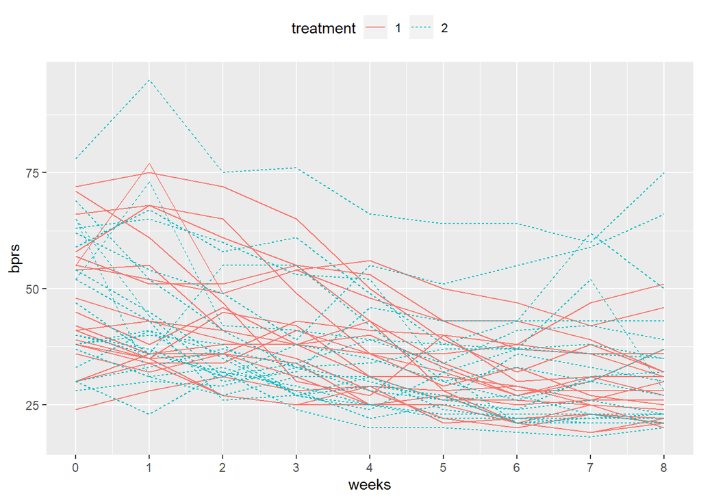

```r
ggplot(bprsl, aes(x = week, y = bprs, group = ID, linetype = treatment)) +
  geom_line(aes(col = treatment)) +
  scale_x_continuous(name = "weeks", breaks = seq(0, 8, 1)) +
  scale_y_continuous(name = "bprs") +
  theme(legend.position = "top")
```

In the plot above you can see how the bprs score changes over time in the individual subjects.

Next, I’ll fit a random intercept model which allows each subject’s intercept to differ from other subjects.

```r
bprs_ref <- lmer(bprs ~ week + treatment + (1 | ID), data = bprsl, REML = FALSE)
summary(bprs_ref)
```

```
## Linear mixed model fit by maximum likelihood  ['lmerMod']
## Formula: bprs ~ week + treatment + (1 | ID)
##    Data: bprsl
##
##      AIC      BIC   logLik deviance df.resid
##   2582.9   2602.3  -1286.5   2572.9      355
##
## Scaled residuals:
##      Min       1Q   Median       3Q      Max
## -2.27506 -0.59909 -0.06104  0.44226  3.15835
##
## Random effects:
##  Groups   Name        Variance Std.Dev.
##  ID       (Intercept) 97.39    9.869
##  Residual             54.23    7.364
## Number of obs: 360, groups:  ID, 40
##
## Fixed effects:
##             Estimate Std. Error t value
## (Intercept)  46.4539     2.3521  19.750
## week         -2.2704     0.1503 -15.104
## treatment2    0.5722     3.2159   0.178
##
## Correlation of Fixed Effects:
##            (Intr) week
## week       -0.256
## treatment2 -0.684  0.000
```

The results remain mostly similar to the results of multiple linear regression model. The t-value of week is high, indicating that tere is an effect of time. The t-value of treatment is low suggesting that no effect of the treatment is found.

Then I’ll fit a random intercept and random slope model, which allows for each subject to differ both in the intercept and the slope.

```r
# create a random intercept and random slope model
bprs_ref1 <- lmer(bprs ~ week + treatment + (week | ID), data = bprsl, REML = FALSE)
summary(bprs_ref1)
```

```
## Linear mixed model fit by maximum likelihood  ['lmerMod']
## Formula: bprs ~ week + treatment + (week | ID)
##    Data: bprsl
##
##      AIC      BIC   logLik deviance df.resid
##   2523.2   2550.4  -1254.6   2509.2      353
##
## Scaled residuals:
##     Min      1Q  Median      3Q     Max
## -2.4655 -0.5150 -0.0920  0.4347  3.7353
##
## Random effects:
##  Groups   Name        Variance Std.Dev. Corr
##  ID       (Intercept) 167.827  12.955
##           week          2.331   1.527   -0.67
##  Residual              36.747   6.062
## Number of obs: 360, groups:  ID, 40
##
## Fixed effects:
##             Estimate Std. Error t value
## (Intercept)  45.9830     2.6470  17.372
## week         -2.2704     0.2713  -8.370
## treatment2    1.5139     3.1392   0.482
##
## Correlation of Fixed Effects:
##            (Intr) week
## week       -0.545
## treatment2 -0.593  0.000
```

And again, the results stay similar to the previous ones. We can compare the two models with ANOVA:

```r
# perform an ANOVA test on the two models
anova(bprs_ref1, bprs_ref)
```

```
## Data: bprsl
## Models:
## bprs_ref: bprs ~ week + treatment + (1 | ID)
## bprs_ref1: bprs ~ week + treatment + (week | ID)
##           npar    AIC    BIC  logLik deviance  Chisq Df          Pr(>Chisq)
## bprs_ref     5 2582.9 2602.3 -1286.5   2572.9
## bprs_ref1    7 2523.2 2550.4 -1254.6   2509.2 63.663  2 0.00000000000001499 ***
## ---
## Signif. codes:  0 '***' 0.001 '**' 0.01 '*' 0.05 '.' 0.1 ' ' 1
```

The ANOVA test shows a likelihood ratio test between the two models. The fit of the models differs significantly. The random intercept and random slope model has a better fit.

Let’s try to improve the model further by allowing for a treatment x time interaction.

```r
bprs_ref2 <- lmer(bprs ~ week * treatment + (week | ID), data = bprsl, REML = FALSE)
summary(bprs_ref2)
```

```
## Linear mixed model fit by maximum likelihood  ['lmerMod']
## Formula: bprs ~ week * treatment + (week | ID)
##    Data: bprsl
##
##      AIC      BIC   logLik deviance df.resid
##   2523.5   2554.5  -1253.7   2507.5      352
##
## Scaled residuals:
##     Min      1Q  Median      3Q     Max
## -2.4747 -0.5256 -0.0866  0.4435  3.7884
##
## Random effects:
##  Groups   Name        Variance Std.Dev. Corr
##  ID       (Intercept) 164.204  12.814
##           week          2.203   1.484   -0.66
##  Residual              36.748   6.062
## Number of obs: 360, groups:  ID, 40
##
## Fixed effects:
##                 Estimate Std. Error t value
## (Intercept)      47.8856     2.9840  16.047
## week             -2.6283     0.3752  -7.006
## treatment2       -2.2911     4.2200  -0.543
## week:treatment2   0.7158     0.5306   1.349
##
## Correlation of Fixed Effects:
##             (Intr) week   trtmn2
## week        -0.668
## treatment2  -0.707  0.473
## wek:trtmnt2  0.473 -0.707 -0.668
```

And then compare this model to the previous one:

```r
anova(bprs_ref2, bprs_ref1)
```

```
## Data: bprsl
## Models:
## bprs_ref1: bprs ~ week + treatment + (week | ID)
## bprs_ref2: bprs ~ week * treatment + (week | ID)
##           npar    AIC    BIC  logLik deviance Chisq Df Pr(>Chisq)
## bprs_ref1    7 2523.2 2550.4 -1254.6   2509.2
## bprs_ref2    8 2523.5 2554.6 -1253.7   2507.5  1.78  1     0.1821
```

The model with interaction does not fit the data better than the model without interaction.

Finally, I’ll plot the observed values side by side with the fitted values from the model with the best fit.

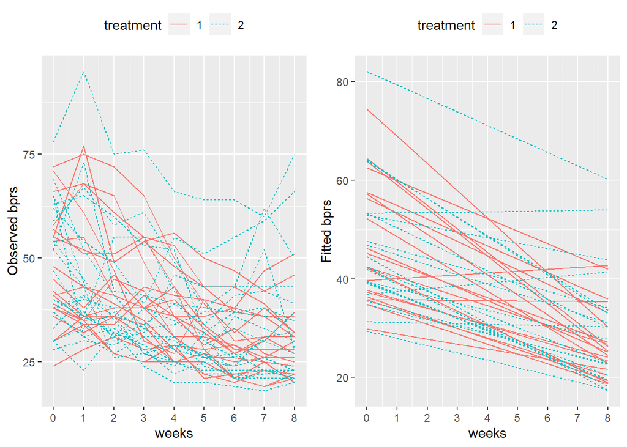

```r
# Create a vector of the fitted values
fitted <- fitted(bprs_ref1)

# Create a new column fitted to bprsl
bprsl <- bprsl %>% mutate(fitted)

# draw the plot of bprsl observed values
graph1 <- ggplot(bprsl, aes(x = week, y = bprs, group = ID, linetype = treatment)) +
  geom_line(aes(col = treatment)) +
  scale_x_continuous(name = "weeks", breaks = seq(0, 8, 1)) +
  scale_y_continuous(name = "Observed bprs") +
  theme(legend.position = "top")

# draw the plot of bprsl fitted values
graph2 <- ggplot(bprsl, aes(x = week, y = fitted, group = ID, linetype = treatment)) +
  geom_line(aes(col = treatment)) +
  scale_x_continuous(name = "weeks", breaks = seq(0, 8, 1)) +
  scale_y_continuous(name = "Fitted bprs") +
  theme(legend.position = "top")

grid.arrange(graph1, graph2, ncol = 2)
```

From the plot above we can see that the fitted values show the general tendency of bprs scores getting lower as the treatments go on.